# Chequeando predicciones

Daniel Gervini

22 de agosto de 2020

# ¿Llegó o no llegó el pico?

Hace tres semanas, a principios de agosto, en [este post](https://dgervini.github.io/Coronavirus/Historia_dos_ciudades.html) hice un análisis de la evolución del coronavirus en Buenos Aires y sus suburbios usando el modelo SIRD, incluyendo un cálculo del $R_0$ y algunas predicciones sobre cuándo podía llegar el pico. Como se explicó en ese post, dado que el $R_0$ nunca había bajado de 1 (y claramente ya no iba a bajar), el pico iba a llegar cuando el *R efectivo* $R_e$ bajara de 1. Lamentablemente hay una confusión persistente en los medios y en los voceros gubernamentales entre el $R_0$ y el $R_e$, que son dos cosas distintas: el $R_e$ es el $R_0$ multiplicado por la fracción de individuos susceptibles. Si el $R_0$ no baja de 1, entonces el pico va a llegar cuando el $R_e$ baje de 1, que es cuando se alcanza la inmunidad de rebaño necesaria para el $R_0$ dado. (Para más detalles ver [este otro post](https://dgervini.github.io/Coronavirus/Inmunidad_de_Rebanio.html) y, más técnicamente, [acá](https://en.wikipedia.org/wiki/Basic_reproduction_number).)

Las conclusiones de los posts anteriores eran que el $R_0$ era de alrededor de 1,04 tanto en la ciudad de Buenos Aires como en los suburbios, por lo que un $R_e$ igual a 1 se iba a obtener cuando se contagiara el 4% de la población, ya que $1.04\times 0.96 = 1$. Un 4% de la población sería alrededor de 115.000 habitantes en la ciudad y 430.000 en el conurbano. Por lo tanto, se pronosticaba que el pico estaba ya prácticamente ocurriendo en la ciudad, mientras que en el conurbano iba a llegar recién a principios de septiember.

¿Qué muestran los datos actuales?

## Ciudad de Buenos Aires

Abajo se muestran los gráficos de casos confirmados y muertes diarias hasta el viernes 21 de agosto para la ciudad de Buenos Aires. Los datos son los círculos y la línea roja es una curva de suavizado que permite ver mejor la tendencia de los datos (es decir que la línea roja se obtiene de los *datos mismos*, no del modelo SIRD ni de ningún otro modelo).

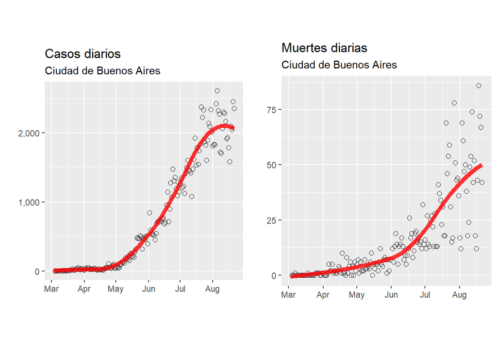

Claramente se ve que la curva roja de casos diarios **ya hizo pico** en la ciudad de Buenos Aires (para ser exactos, el 12 de agosto) y ya está empezando a apuntar hacia abajo. El 12 de agosto había un total de 112.718 casos confirmados, así que el pico ocurrió exactamente cuando el modelo SIRD lo había predicho. La curva de muertes diarias también se está desacelerando, aunque con unos días de retraso, como es de esperarse.

## Conurbano de Buenos Aires

Ahora mostramos los gráficos de casos confirmados y muertes diarias hasta el viernes 21 de agosto para el conurbano bonaerense.

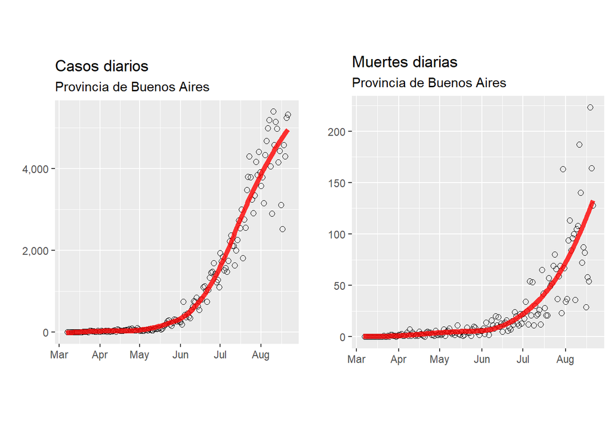

Claramente la curva de casos diarios todavía no hizo pico en el conurbano pero ya se observa una **leve desaceleración**. Esto también es consistente con las predicciones del modelo SIRD: al día de hoy hay un total de 205.069 casos confirmados, y el modelo predice que el pico se alcanzará cuando se llegue a un total de 430.000 casos, para lo que faltan aproximadamente dos o tres semanas.

[Back to blog](https://sites.uwm.edu/gervini/coronavirus-blog/)